# Assignment 12: Predictive Modeling - Part 3

*How to do it?*:

- Open the Rmarkdown file of this assignment (link) in Rstudio.
- Right under each **question**, insert a code chunk (you can use the hotkey `Ctrl + Alt + I` to add a code chunk) and code the solution for the question.
- `Knit` the rmarkdown file (hotkey: `Ctrl + Alt + K`) to export an html.
- Publish the html file to your Githiub Page.

*Submission*: Submit the link on Github of the assignment to Blackboard.

1. Install the package `mlbench` and use the follows to import the data

```r
library(mlbench)
data(PimaIndiansDiabetes)
df <- PimaIndiansDiabetes
```

- Set seed to be 2020.
- The target variable is `diabetes`
- Partition the data into 80% training and 20% testing.

```r
library(tidyverse)
library(rpart)
library(caret)
view(df)
names(df)
```

```
## [1] "pregnant" "glucose"  "pressure" "triceps"  "insulin"  "mass"     "pedigree"
## [8] "age"      "diabetes"
```

```r
#set the target variable as diabetes
names(df)[9] <- 'diabetes'

#remove missing values
df = drop_na(df)

#split the data to train and test
set.seed(2020)
splitIndex <- createDataPartition(df$diabetes, p = .80, list = FALSE)
df_train <- df[splitIndex,]
df_test <- df[-splitIndex,]
```

2. Use cross-validation of 30 folds to tune random forest (method=‘rf’). What is the `mtry` value that produces the greatest accuracy?

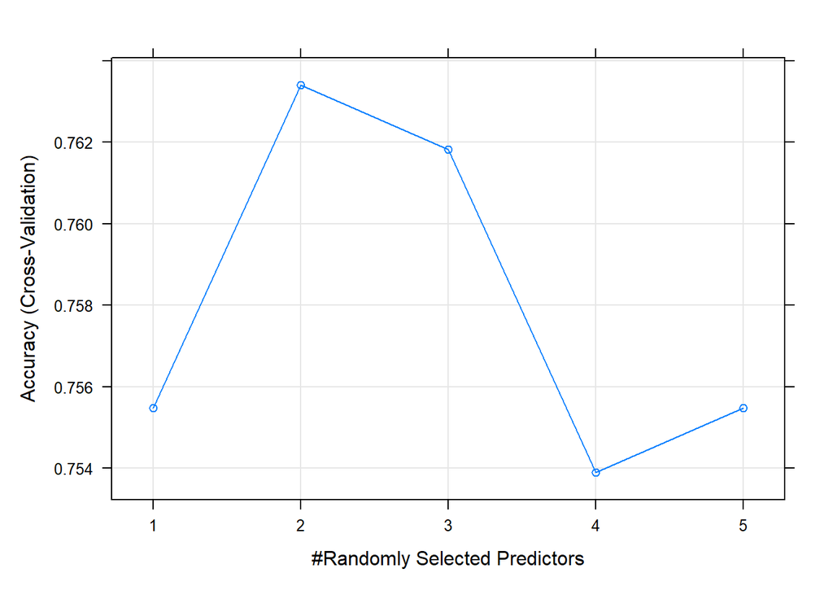

```r
# Decide the range of the maxdepth to search for the best
tuneGrid = expand.grid(mtry = 1:5)
# Tell caret to do 10 - fold cross-Validation
trControl = trainControl(method = "cv",
                         number = 30)
# train a forest using above setup
forest_rf <- train(diabetes~., data=df_train,
                                method = "rf",
                                trControl = trControl,
                                tuneGrid = tuneGrid)
plot(forest_rf)
```

The final value used for the model to produce the best accuracy was mtry = 2. ——-

3. Use cross-validation with of 30 folds to tune random forest (method=‘ranger’). What are the parameters that produce the greatest accuracy?

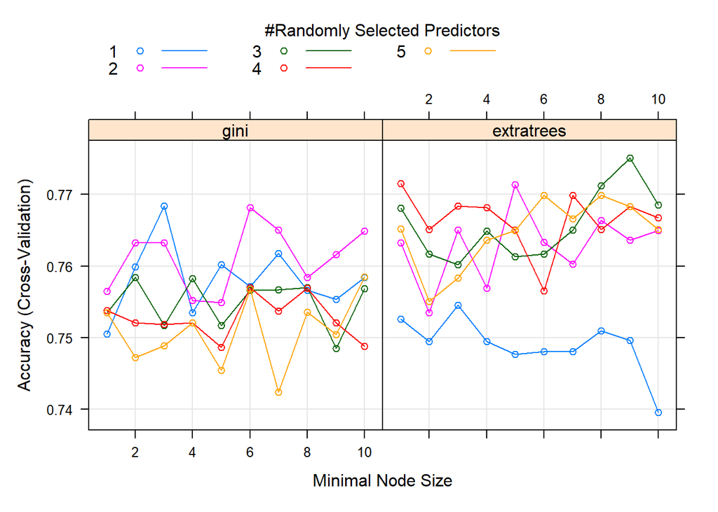

```r
trControl = trainControl(method = "cv",
                         number = 30)
tuneGrid = expand.grid(mtry = 1:5,
                       splitrule = c('gini', 'extratrees'),
                       min.node.size = c(1:10))
forest_ranger <- train(diabetes~., data=df_train,
                    method = "ranger",
                    trControl = trControl,
                    tuneGrid = tuneGrid)
plot(forest_ranger)
```

4. Go to https://topepo.github.io/caret/available-models.html and pick a classification model. Tune the classification model using cross-validation of 30 folds.

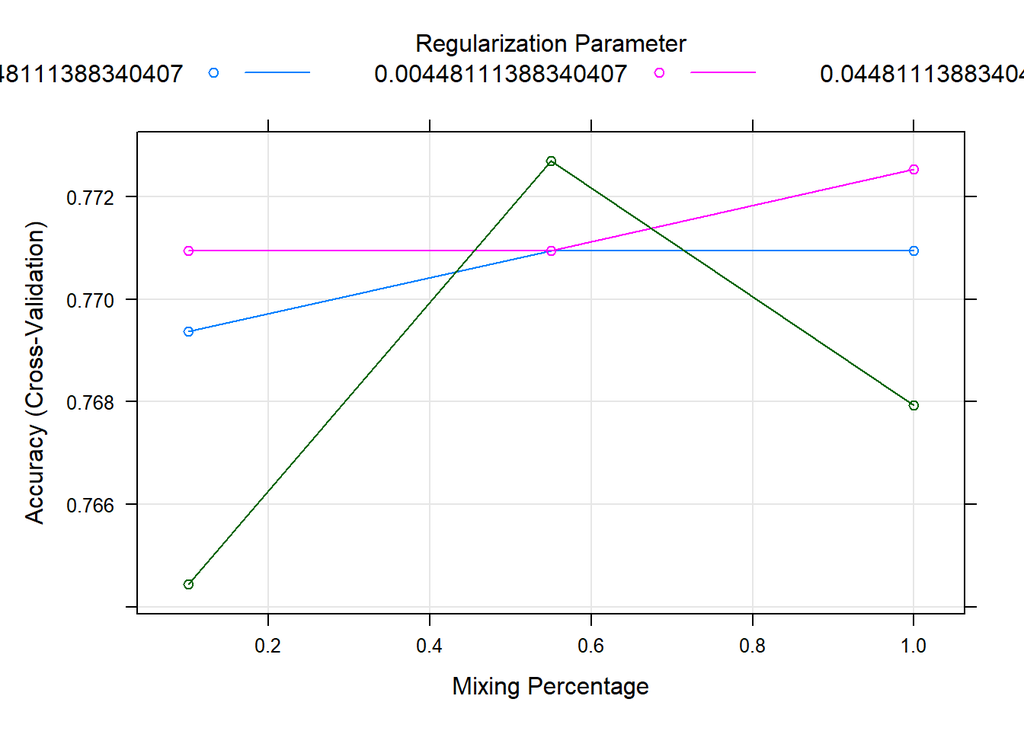

```r
trControl = trainControl(method = "cv",
                         number = 30)
forest_ranger1 <- train(diabetes~., data=df_train,
                    method = "glmnet",
                    trControl = trControl)
plot(forest_ranger1)
```

5. Pick three models at [this link](https://topepo.github.io/caret/available-models.html) to compare using 15-fold cross validation method. Evaluate the accuracy of the final model on the test data. What is the best model?

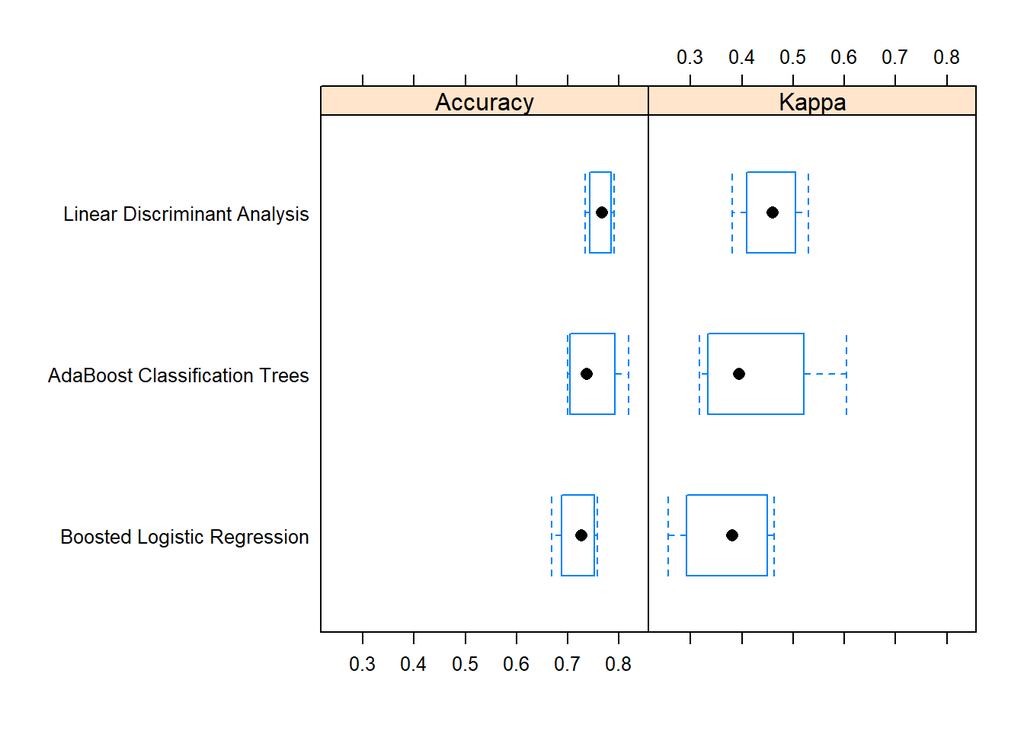

```r
trControl = trainControl(method = "cv",
                         number = 4)

ada_boost <- train(diabetes~., data=df_train,
                                method = "adaboost",
                                trControl = trControl)
boosted_log_reg <- train(diabetes~., data=df_train,
                    method = "LogitBoost",
                                trControl = trControl)
lin_disc_analy <- train(diabetes~., data=df_train,
                                method = "lda",
                                trControl = trControl)

results <- resamples(list('AdaBoost Classification Trees' = ada_boost, 'Boosted Logistic Regression' = boosted_log_reg, 'Linear Discriminant Analysis'= lin_disc_analy))

bwplot(results)
```

```r
pred <- predict(ada_boost, df_test)
cm <- confusionMatrix(data = pred, reference = df_test$diabetes, positive = "pos")
cm$overall[1]
```

```
##  Accuracy
## 0.7712418
```

```r
pred <- predict(boosted_log_reg, df_test)
cm <- confusionMatrix(data = pred, reference = df_test$diabetes, positive = "pos")
cm$overall[1]
```

```
##  Accuracy
## 0.7712418
```

```r
pred <- predict(lin_disc_analy, df_test)
cm <- confusionMatrix(data = pred, reference = df_test$diabetes, positive = "pos")
cm$overall[1]
```

```
##  Accuracy
## 0.7908497
```

## Of the three models, the LDA is the best one that produces the highest accuracy score.

```r
library(tidyverse)
library(caret)

df1 <- read_csv('C:/Users/student/Documents/Fall 2021/MATH 421/Math421/adult.csv')
view(df1)
df1 = drop_na(df1)

set.seed(2020)
splitIndex <- createDataPartition(df1$income, p = .80, list = FALSE)
df1_train <- df1[splitIndex,]
df1_test <- df1[-splitIndex,]
```

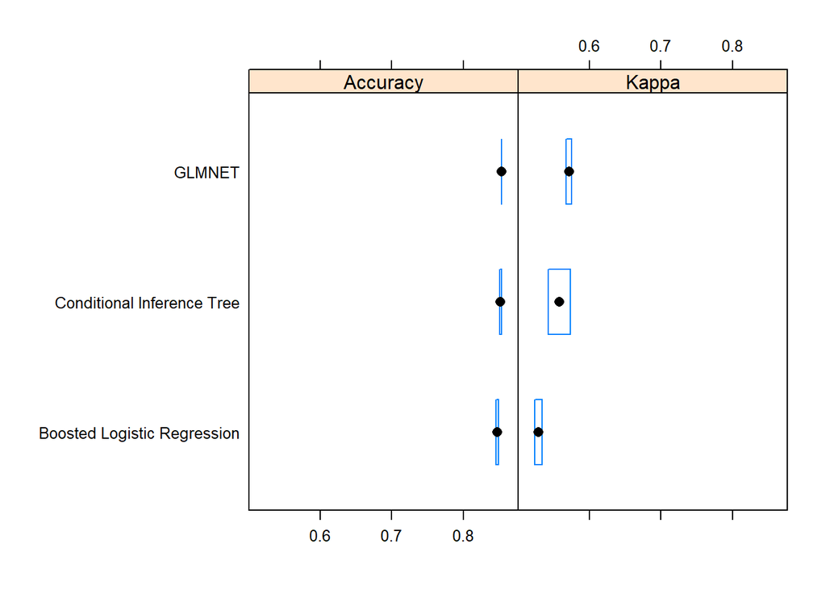

```r
trControl = trainControl(method = "cv",
                         number = 2)
cond_inf_tree <- train(income~., data=df1_train,
                                method = "ctree",
                                trControl = trControl)
boosted_log_reg <- train(income~., data=df1_train,
                    method = "LogitBoost",
                                trControl = trControl)
gen_lin_mod <- train(income~., data=df1_train,
                                method = "glmnet",
                                trControl = trControl)

results <- resamples(list('Conditional Inference Tree' = cond_inf_tree, 'Boosted Logistic Regression' = boosted_log_reg, 'GLMNET'= gen_lin_mod))

bwplot(results)
```

- `Credit card default` dataset ([link](https://www.kaggle.com/uciml/default-of-credit-card-clients-dataset)) where the target variable is `default.payment.next.month`

```r
library(tidyverse)
library(caret)

a <- read_csv("C:/Users/student/Documents/Fall 2021/MATH 421/Math421/UCI_Credit_Card.csv")
view(a)

set.seed(2020)
names(a)[25] <- 'target'
splitIndex <- createDataPartition(a$target, p = .80, list = FALSE)
a_train <- a[splitIndex,]
a_test <- a[-splitIndex,]
```

```r
trControl = trainControl(method = "cv",
                         number = 4)
knn <- train(target~., data=a_train, method = "knn", trControl = trControl)
kknn <- train(target~., data=a_train, method = "kknn", trControl = trControl)
tree <- train(target~., data=a_train, method = "rpart2", trControl = trControl)
```

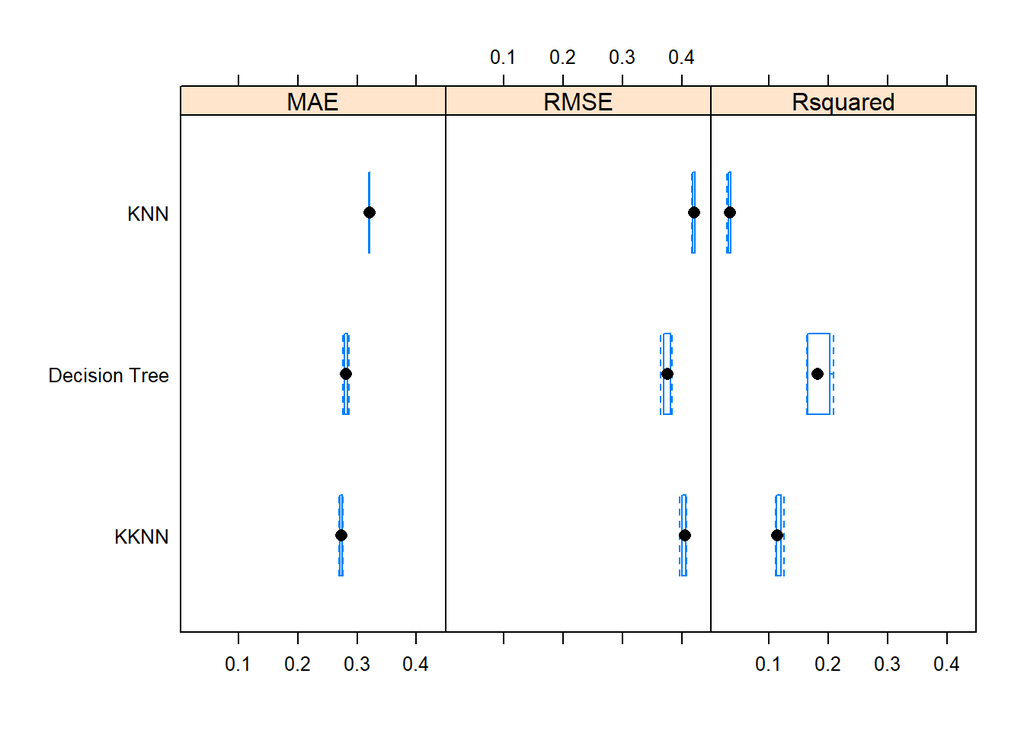

```r
results <- resamples(list('KNN' = knn,
                          'KKNN' = kknn,
                          'Decision Tree'= tree))

bwplot(results)
```